# FINAL_Term_Deposit_Project_GaneshBalusait

```python
import pandas as pd
import numpy as np
import matplotlib.pyplot as plt
%matplotlib inline
import seaborn as sns
```

```python
df = pd.read_csv('bank-full.csv')
df.head(10)
```

|  | age | job | marital | education | default | balance | housing | loan | contact | day | month | duration | campaign | pdays | previous | poutcome | Target |
| --- | --- | --- | --- | --- | --- | --- | --- | --- | --- | --- | --- | --- | --- | --- | --- | --- | --- |
| 0 | 58 | management | married | tertiary | no | 2143 | yes | no | unknown | 5 | may | 261 | 1 | -1 | 0 | unknown | no |
| 1 | 44 | technician | single | secondary | no | 29 | yes | no | unknown | 5 | may | 151 | 1 | -1 | 0 | unknown | no |
| 2 | 33 | entrepreneur | married | secondary | no | 2 | yes | yes | unknown | 5 | may | 76 | 1 | -1 | 0 | unknown | no |
| 3 | 47 | blue-collar | married | unknown | no | 1506 | yes | no | unknown | 5 | may | 92 | 1 | -1 | 0 | unknown | no |
| 4 | 33 | unknown | single | unknown | no | 1 | no | no | unknown | 5 | may | 198 | 1 | -1 | 0 | unknown | no |
| 5 | 35 | management | married | tertiary | no | 231 | yes | no | unknown | 5 | may | 139 | 1 | -1 | 0 | unknown | no |
| 6 | 28 | management | single | tertiary | no | 447 | yes | yes | unknown | 5 | may | 217 | 1 | -1 | 0 | unknown | no |
| 7 | 42 | entrepreneur | divorced | tertiary | yes | 2 | yes | no | unknown | 5 | may | 380 | 1 | -1 | 0 | unknown | no |
| 8 | 58 | retired | married | primary | no | 121 | yes | no | unknown | 5 | may | 50 | 1 | -1 | 0 | unknown | no |
| 9 | 43 | technician | single | secondary | no | 593 | yes | no | unknown | 5 | may | 55 | 1 | -1 | 0 | unknown | no |

```python
df.shape
```

```
(45211, 17)
```

###### Observations

```python
df.describe().transpose()
```

|  | count | mean | std | min | 25% | 50% | 75% | max |
| --- | --- | --- | --- | --- | --- | --- | --- | --- |
| age | 45211.0 | 40.936210 | 10.618762 | 18.0 | 33.0 | 39.0 | 48.0 | 95.0 |
| balance | 45211.0 | 1362.272058 | 3044.765829 | -8019.0 | 72.0 | 448.0 | 1428.0 | 102127.0 |
| day | 45211.0 | 15.806419 | 8.322476 | 1.0 | 8.0 | 16.0 | 21.0 | 31.0 |
| duration | 45211.0 | 258.163080 | 257.527812 | 0.0 | 103.0 | 180.0 | 319.0 | 4918.0 |
| campaign | 45211.0 | 2.763841 | 3.098021 | 1.0 | 1.0 | 2.0 | 3.0 | 63.0 |
| pdays | 45211.0 | 40.197828 | 100.128746 | -1.0 | -1.0 | -1.0 | -1.0 | 871.0 |
| previous | 45211.0 | 0.580323 | 2.303441 | 0.0 | 0.0 | 0.0 | 0.0 | 275.0 |

##### Observations

- Age columns has a minimum of 18 and maximum of 95 value - the campaign covers a wide age group of clients.
- Balance column there are clients whose bank balance is in negative as well.
- Day column has a min of 1, max of 31 and mean of 15.
- outliers in the campaign and previous columns.

```python
# No Missing Values

df.info()
```

```
<class 'pandas.core.frame.DataFrame'>
RangeIndex: 45211 entries, 0 to 45210
Data columns (total 17 columns):
 #   Column     Non-Null Count  Dtype
---  ------     --------------  -----
 0   age        45211 non-null  int64
 1   job        45211 non-null  object
 2   marital    45211 non-null  object
 3   education  45211 non-null  object
 4   default    45211 non-null  object
 5   balance    45211 non-null  int64
 6   housing    45211 non-null  object
 7   loan       45211 non-null  object
 8   contact    45211 non-null  object
 9   day        45211 non-null  int64
 10  month      45211 non-null  object
 11  duration   45211 non-null  int64
 12  campaign   45211 non-null  int64
 13  pdays      45211 non-null  int64
 14  previous   45211 non-null  int64
 15  poutcome   45211 non-null  object
 16  Target     45211 non-null  object
dtypes: int64(7), object(10)
memory usage: 5.9+ MB
```

###### Observations

- Few columns types are integer and object is for categorical
- There is no null/Missing Values in dataset

```python
df.isnull().sum()
```

```
age          0
job          0
marital      0
education    0
default      0
balance      0
housing      0
loan         0
contact      0
day          0
month        0
duration     0
campaign     0
pdays        0
previous     0
poutcome     0
Target       0
dtype: int64
```

```python
def examine_data(df):
    for name in df.columns:
        print('---------')
        print(df[name].dtype)
        if df[name].dtype is np.dtype('object'):
            print(df[name].value_counts())
            print('Name:',name)
examine_data(df)
```

```
---------
int64
---------
object
blue-collar      9732
management       9458
technician       7597
admin.           5171
services         4154
retired          2264
self-employed    1579
entrepreneur     1487
unemployed       1303
housemaid        1240
student           938
unknown           288
Name: job, dtype: int64
Name: job
---------
object
married     27214
single      12790
divorced     5207
Name: marital, dtype: int64
Name: marital
---------
object
secondary    23202
tertiary     13301
primary       6851
unknown       1857
Name: education, dtype: int64
Name: education
---------
object
no     44396
yes      815
Name: default, dtype: int64
Name: default
---------
```

[output cut: 45 more lines]

```
int64
---------
object
unknown    36959
failure     4901
other       1840
success     1511
Name: poutcome, dtype: int64
Name: poutcome
---------
object
no     39922
yes     5289
Name: Target, dtype: int64
Name: Target
```

##### Observations:

- for each int and object column total unique counts. including depedent variables.
- The ratio of yes to no its a big difference, looks like indicates its a highly unbalanced dataset.

```python
df.head()
```

|  | age | job | marital | education | default | balance | housing | loan | contact | day | month | duration | campaign | pdays | previous | poutcome | Target |
| --- | --- | --- | --- | --- | --- | --- | --- | --- | --- | --- | --- | --- | --- | --- | --- | --- | --- |
| 0 | 58 | management | married | tertiary | no | 2143 | yes | no | unknown | 5 | may | 261 | 1 | -1 | 0 | unknown | no |
| 1 | 44 | technician | single | secondary | no | 29 | yes | no | unknown | 5 | may | 151 | 1 | -1 | 0 | unknown | no |
| 2 | 33 | entrepreneur | married | secondary | no | 2 | yes | yes | unknown | 5 | may | 76 | 1 | -1 | 0 | unknown | no |
| 3 | 47 | blue-collar | married | unknown | no | 1506 | yes | no | unknown | 5 | may | 92 | 1 | -1 | 0 | unknown | no |
| 4 | 33 | unknown | single | unknown | no | 1 | no | no | unknown | 5 | may | 198 | 1 | -1 | 0 | unknown | no |

#### Univariate Analysis

- Observations for each indepeent variables to plot the histogram and boxplot for numerical features.
- Count plot for categorical features.
- Boxplot finding out the outlier for each numerical features.

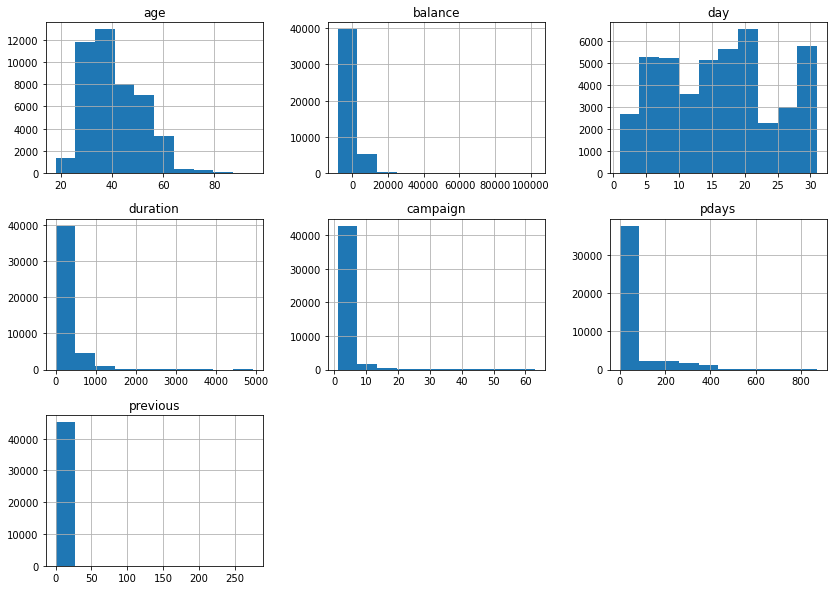

```python
df.hist(bins=10, figsize=(14,10))
plt.show()
```

```python
df.columns
```

```
Index(['age', 'job', 'marital', 'education', 'default', 'balance', 'housing',
       'loan', 'contact', 'day', 'month', 'duration', 'campaign', 'pdays',
       'previous', 'poutcome', 'Target'],
      dtype='object')
```

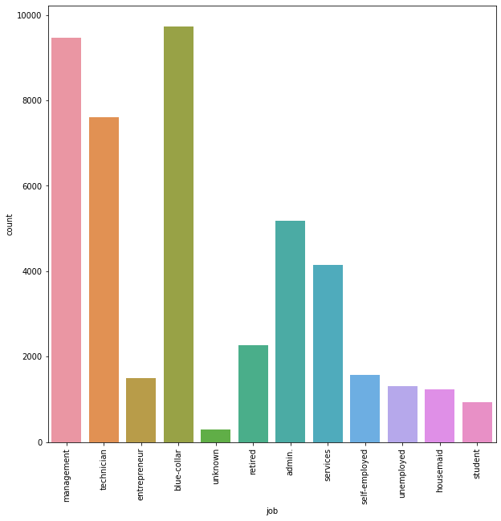

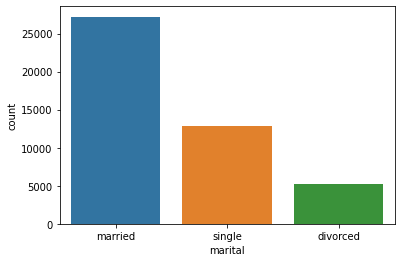

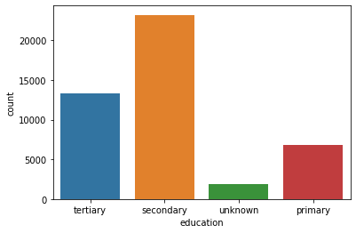

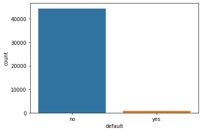

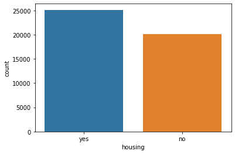

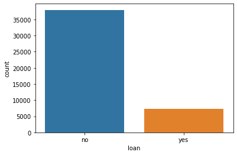

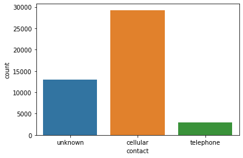

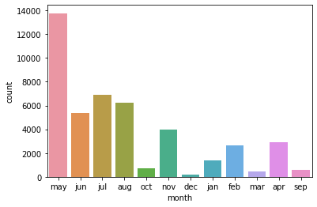

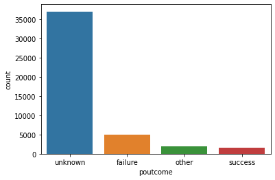

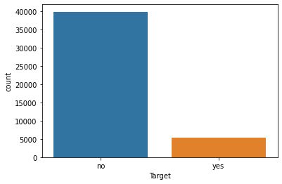

```python
plt.figure(figsize=(10,10))
for i in ['job', 'marital', 'education', 'default', 'housing',
       'loan', 'contact', 'month', 'poutcome', 'Target']:
    print()
    sns.countplot(df[i])
    if i == 'job':
       plt.xticks(rotation='vertical')

    plt.show()
```

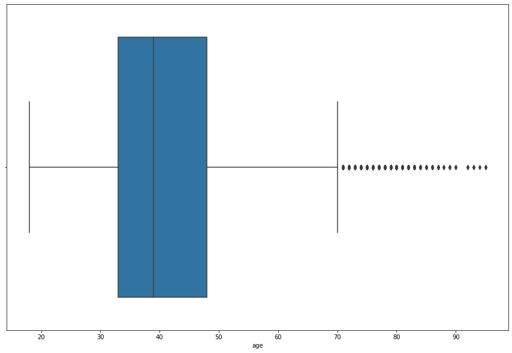

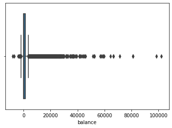

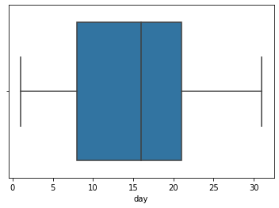

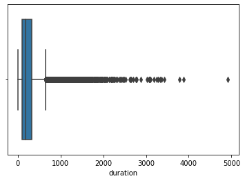

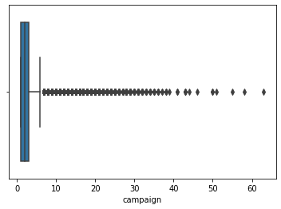

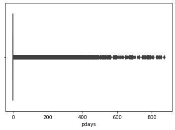

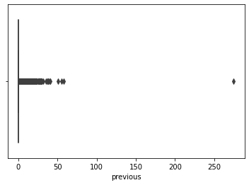

```python
plt.figure(figsize=(15,10))
for i in ['age', 'balance', 'day', 'duration', 'campaign', 'pdays', 'previous']:
    sns.boxplot(df[i])
    plt.show()
```

```python
df.groupby('Target').mean()
```

| Target | age | balance | day | duration | campaign | pdays | previous |
| --- | --- | --- | --- | --- | --- | --- | --- |
| no | 40.838986 | 1303.714969 | 15.892290 | 221.182806 | 2.846350 | 36.421372 | 0.502154 |
| yes | 41.670070 | 1804.267915 | 15.158253 | 537.294574 | 2.141047 | 68.702968 | 1.170354 |

##### Observations

- There is no age group variation, term deposit vs turned down.

#### Bivariate Analysis

- Relationship between predicted variabe and target column - (barplot, boxplot and pairplot).

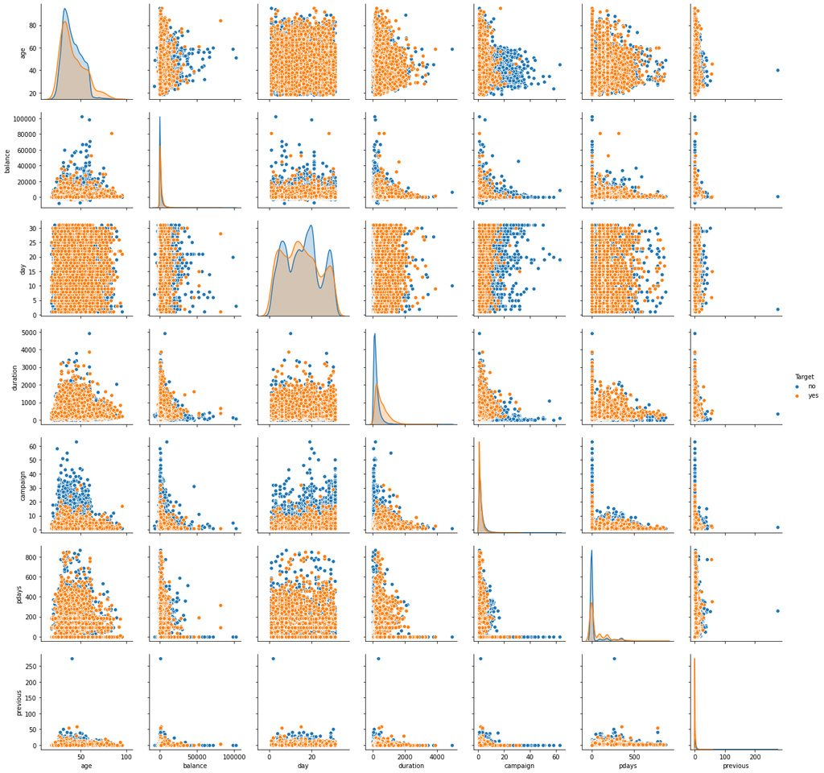

```python
sns.pairplot(df,hue='Target',diag_kind='kde')
```

```python
df.head()
```

|  | age | job | marital | education | default | balance | housing | loan | contact | day | month | duration | campaign | pdays | previous | poutcome | Target |
| --- | --- | --- | --- | --- | --- | --- | --- | --- | --- | --- | --- | --- | --- | --- | --- | --- | --- |
| 0 | 58 | management | married | tertiary | no | 2143 | yes | no | unknown | 5 | may | 261 | 1 | -1 | 0 | unknown | no |
| 1 | 44 | technician | single | secondary | no | 29 | yes | no | unknown | 5 | may | 151 | 1 | -1 | 0 | unknown | no |
| 2 | 33 | entrepreneur | married | secondary | no | 2 | yes | yes | unknown | 5 | may | 76 | 1 | -1 | 0 | unknown | no |
| 3 | 47 | blue-collar | married | unknown | no | 1506 | yes | no | unknown | 5 | may | 92 | 1 | -1 | 0 | unknown | no |
| 4 | 33 | unknown | single | unknown | no | 1 | no | no | unknown | 5 | may | 198 | 1 | -1 | 0 | unknown | no |

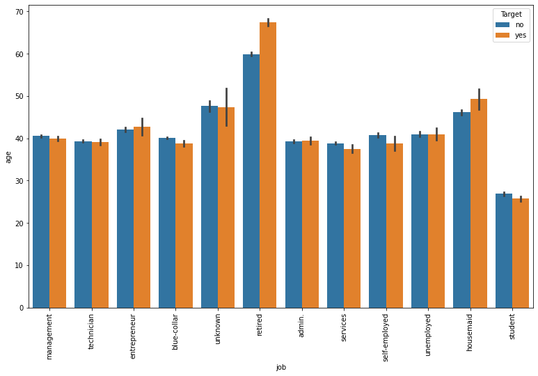

```python
plt.figure(figsize=(13,8))
sns.barplot(df['job'],df['age'],hue=df['Target'])
plt.xticks(rotation='vertical')
plt.show()
```

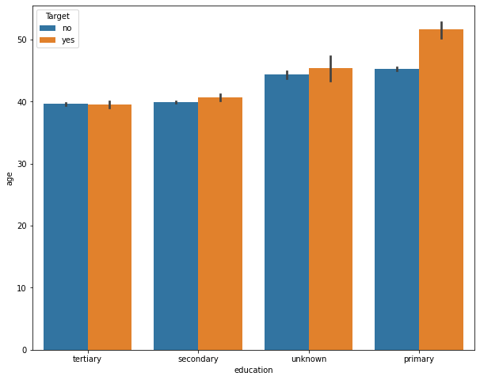

```python
plt.figure(figsize=(10,8))
sns.barplot(df['education'],df['age'],hue=df['Target'])
plt.show()
```

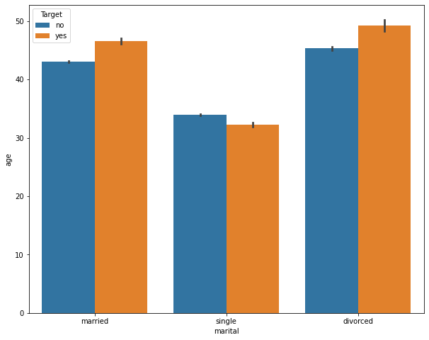

```python
plt.figure(figsize=(10,8))
sns.barplot(df['marital'],df['age'],hue=df['Target'])
plt.show()
```

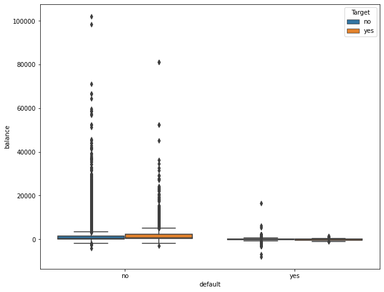

```python
plt.figure(figsize=(10,8))
sns.boxplot(df['default'],df['balance'],hue=df['Target'])
plt.show()
```

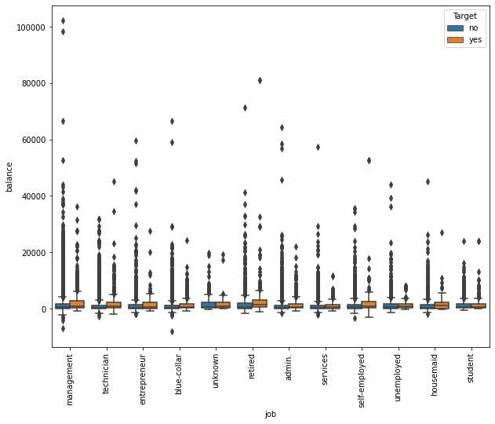

```python
plt.figure(figsize=(10,8))
g=sns.boxplot(df['job'],df['balance'],hue=df['Target'])
g.set_xticklabels(df['job'].unique(),rotation=90)
plt.show()
```

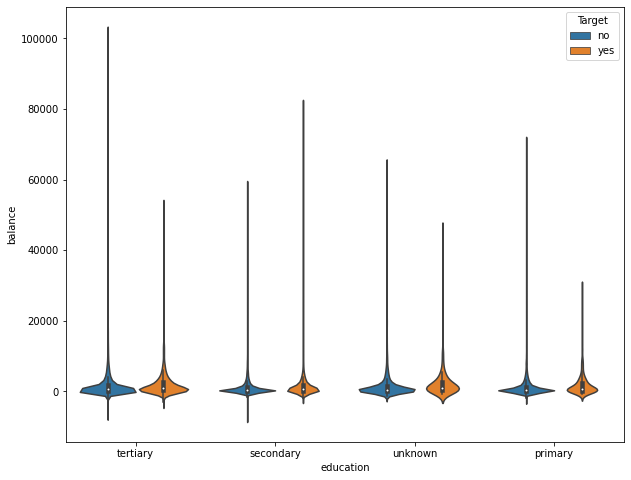

```python
plt.figure(figsize=(10,8))
sns.violinplot(x='education',y='balance',data=df,hue=df['Target'])
plt.show()
```

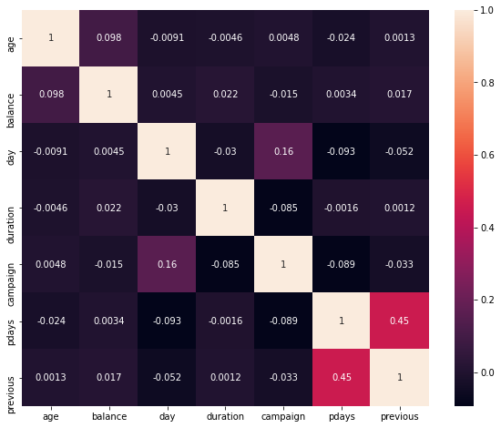

```python
plt.figure(figsize=(10,8))
sns.heatmap(df.corr(),annot=True)
```

## Deliverable – 2 (Prepare the data for analytics)

```python
df.head()
```

|  | age | job | marital | education | default | balance | housing | loan | contact | day | month | duration | campaign | pdays | previous | poutcome | Target |
| --- | --- | --- | --- | --- | --- | --- | --- | --- | --- | --- | --- | --- | --- | --- | --- | --- | --- |
| 0 | 58 | management | married | tertiary | no | 2143 | yes | no | unknown | 5 | may | 261 | 1 | -1 | 0 | unknown | no |
| 1 | 44 | technician | single | secondary | no | 29 | yes | no | unknown | 5 | may | 151 | 1 | -1 | 0 | unknown | no |
| 2 | 33 | entrepreneur | married | secondary | no | 2 | yes | yes | unknown | 5 | may | 76 | 1 | -1 | 0 | unknown | no |
| 3 | 47 | blue-collar | married | unknown | no | 1506 | yes | no | unknown | 5 | may | 92 | 1 | -1 | 0 | unknown | no |
| 4 | 33 | unknown | single | unknown | no | 1 | no | no | unknown | 5 | may | 198 | 1 | -1 | 0 | unknown | no |

##### LabelEncode the categorical variables

```python
from sklearn.preprocessing import LabelEncoder
le = LabelEncoder()
for i in ['job','marital','education','default','housing','loan','contact','month','poutcome','Target']:
    df[i] = le.fit_transform(df[i])

    #print(dict(zip(i,df[i].items())))
    print(f'{i}:', dict(zip(le.classes_, range(len(le.classes_)))))
```

```
job: {'admin.': 0, 'blue-collar': 1, 'entrepreneur': 2, 'housemaid': 3, 'management': 4, 'retired': 5, 'self-employed': 6, 'services': 7, 'student': 8, 'technician': 9, 'unemployed': 10, 'unknown': 11}
marital: {'divorced': 0, 'married': 1, 'single': 2}
education: {'primary': 0, 'secondary': 1, 'tertiary': 2, 'unknown': 3}
default: {'no': 0, 'yes': 1}
housing: {'no': 0, 'yes': 1}
loan: {'no': 0, 'yes': 1}
contact: {'cellular': 0, 'telephone': 1, 'unknown': 2}
month: {'apr': 0, 'aug': 1, 'dec': 2, 'feb': 3, 'jan': 4, 'jul': 5, 'jun': 6, 'mar': 7, 'may': 8, 'nov': 9, 'oct': 10, 'sep': 11}
poutcome: {'failure': 0, 'other': 1, 'success': 2, 'unknown': 3}
Target: {'no': 0, 'yes': 1}
```

##### Observations

- Categorical variable, encoding label with a value 0 to (n-1).

```python
df.info()
```

```
<class 'pandas.core.frame.DataFrame'>
RangeIndex: 45211 entries, 0 to 45210
Data columns (total 17 columns):
 #   Column     Non-Null Count  Dtype
---  ------     --------------  -----
 0   age        45211 non-null  int64
 1   job        45211 non-null  int64
 2   marital    45211 non-null  int64
 3   education  45211 non-null  int64
 4   default    45211 non-null  int64
 5   balance    45211 non-null  int64
 6   housing    45211 non-null  int64
 7   loan       45211 non-null  int64
 8   contact    45211 non-null  int64
 9   day        45211 non-null  int64
 10  month      45211 non-null  int64
 11  duration   45211 non-null  int64
 12  campaign   45211 non-null  int64
 13  pdays      45211 non-null  int64
 14  previous   45211 non-null  int64
 15  poutcome   45211 non-null  int64
 16  Target     45211 non-null  int64
dtypes: int64(17)
memory usage: 5.9 MB
```

##### Observations

- All the columns are convert into int

```python
df.tail()
```

|  | age | job | marital | education | default | balance | housing | loan | contact | day | month | duration | campaign | pdays | previous | poutcome | Target |
| --- | --- | --- | --- | --- | --- | --- | --- | --- | --- | --- | --- | --- | --- | --- | --- | --- | --- |
| 45206 | 51 | 9 | 1 | 2 | 0 | 825 | 0 | 0 | 0 | 17 | 9 | 977 | 3 | -1 | 0 | 3 | 1 |
| 45207 | 71 | 5 | 0 | 0 | 0 | 1729 | 0 | 0 | 0 | 17 | 9 | 456 | 2 | -1 | 0 | 3 | 1 |
| 45208 | 72 | 5 | 1 | 1 | 0 | 5715 | 0 | 0 | 0 | 17 | 9 | 1127 | 5 | 184 | 3 | 2 | 1 |
| 45209 | 57 | 1 | 1 | 1 | 0 | 668 | 0 | 0 | 1 | 17 | 9 | 508 | 4 | -1 | 0 | 3 | 0 |
| 45210 | 37 | 2 | 1 | 1 | 0 | 2971 | 0 | 0 | 0 | 17 | 9 | 361 | 2 | 188 | 11 | 1 | 0 |

##### Transform the data i.e. scale / normalize if required

###### standardScalar() --> scale down the feature into standard normizlation distribution, mean = 0 and standard divation =1.

```python
from sklearn.preprocessing import StandardScaler
scaler = StandardScaler()

# scaler = scaler.fit_transform(features)
# df[col_name] = scaler
# X_scalar = pd.DataFrame(df)
# X_scalar.head()
X = df.drop('Target',axis=1)
y = df['Target']
X_scaler = scaler.fit_transform(X)
X_scaler = pd.DataFrame(X_scaler,columns=X.columns)
X_scaler.head()
```

|  | age | job | marital | education | default | balance | housing | loan | contact | day | month | duration | campaign | pdays | previous | poutcome |
| --- | --- | --- | --- | --- | --- | --- | --- | --- | --- | --- | --- | --- | --- | --- | --- | --- |
| 0 | 1.606965 | -0.103820 | -0.275762 | 1.036362 | -0.13549 | 0.256419 | 0.893915 | -0.436803 | 1.514306 | -1.298476 | 0.823773 | 0.011016 | -0.569351 | -0.411453 | -0.25194 | 0.444898 |
| 1 | 0.288529 | 1.424008 | 1.368372 | -0.300556 | -0.13549 | -0.437895 | 0.893915 | -0.436803 | 1.514306 | -1.298476 | 0.823773 | -0.416127 | -0.569351 | -0.411453 | -0.25194 | 0.444898 |
| 2 | -0.747384 | -0.714951 | -0.275762 | -0.300556 | -0.13549 | -0.446762 | 0.893915 | 2.289359 | 1.514306 | -1.298476 | 0.823773 | -0.707361 | -0.569351 | -0.411453 | -0.25194 | 0.444898 |
| 3 | 0.571051 | -1.020516 | -0.275762 | 2.373280 | -0.13549 | 0.047205 | 0.893915 | -0.436803 | 1.514306 | -1.298476 | 0.823773 | -0.645231 | -0.569351 | -0.411453 | -0.25194 | 0.444898 |
| 4 | -0.747384 | 2.035139 | 1.368372 | 2.373280 | -0.13549 | -0.447091 | -1.118674 | -0.436803 | 1.514306 | -1.298476 | 0.823773 | -0.233620 | -0.569351 | -0.411453 | -0.25194 | 0.444898 |

##### Observations

- Applying Standard Scaler to the entire dataframe.

#### Create the training set and test set in ratio of 70:30

```python
from sklearn.model_selection import train_test_split

X_train, X_test, y_train, y_test = train_test_split(X_scaler, y, test_size=0.30, random_state=1)
```

```python
X_train.shape, X_test.shape, y_train.shape, y_test.shape
```

```
((31647, 16), (13564, 16), (31647,), (13564,))
```

```python
X_train.head()
```

|  | age | job | marital | education | default | balance | housing | loan | contact | day | month | duration | campaign | pdays | previous | poutcome |
| --- | --- | --- | --- | --- | --- | --- | --- | --- | --- | --- | --- | --- | --- | --- | --- | --- |
| 6149 | -0.841558 | -1.020516 | -0.275762 | -0.300556 | 7.380625 | -0.525587 | 0.893915 | -0.436803 | 1.514306 | 1.344997 | 0.823773 | 0.655614 | -0.569351 | -0.411453 | -0.25194 | 0.444898 |
| 12403 | -0.653211 | -1.326082 | 1.368372 | -0.300556 | -0.135490 | -0.604412 | 0.893915 | 2.289359 | 1.514306 | 1.344997 | 0.158632 | -0.571452 | 0.399020 | -0.411453 | -0.25194 | 0.444898 |
| 21645 | -0.841558 | 1.424008 | -0.275762 | -0.300556 | -0.135490 | -0.360055 | 0.893915 | -0.436803 | -0.713012 | 0.383734 | -1.504223 | -0.350114 | -0.246560 | -0.411453 | -0.25194 | 0.444898 |
| 29580 | -0.464863 | -1.020516 | -0.275762 | -0.300556 | 7.380625 | -0.443150 | -1.118674 | 2.289359 | -0.713012 | -1.538792 | -0.839081 | -0.420010 | 0.399020 | -0.411453 | -0.25194 | 0.444898 |
| 31245 | -1.689124 | 1.118442 | 1.368372 | -0.300556 | -0.135490 | -0.287799 | -1.118674 | -0.436803 | -0.713012 | -1.538792 | 0.491202 | -0.664647 | -0.569351 | -0.411453 | -0.25194 | 0.444898 |

#### Deliverable – 3 (create the ensemble model)

###### Non-Ensemble Classifiers

- Logistic Regression
- Decision Tree

##### Logistic Regression - turning into hyper parameter trying to fit the best model

```python
from sklearn.linear_model import LogisticRegression

model = LogisticRegression(random_state=7)
model.fit(X_train,y_train)
```

```
LogisticRegression(C=1.0, class_weight=None, dual=False, fit_intercept=True,
          intercept_scaling=1, max_iter=100, multi_class='warn',
          n_jobs=None, penalty='l2', random_state=7, solver='warn',
          tol=0.0001, verbose=0, warm_start=False)
```

```python
y_predict = model.predict(X_test)
```

```python
model_score = model.score(X_test,y_test)
model_score
```

```
0.8910350928929519
```

```python
model.get_params()
```

```
{'C': 1.0,
 'class_weight': None,
 'dual': False,
 'fit_intercept': True,
 'intercept_scaling': 1,
 'max_iter': 100,
 'multi_class': 'warn',
 'n_jobs': None,
 'penalty': 'l2',
 'random_state': 7,
 'solver': 'warn',
 'tol': 0.0001,
 'verbose': 0,
 'warm_start': False}
```

##### checking each solver in penality=l2 and c=0.75

```python
train_score=[]
test_score=[]
solver = ['newton-cg','lbfgs','liblinear','sag','saga']
for i in solver:
    model1 = LogisticRegression(random_state=42,penalty='l2',C=0.75,solver=i)
    model1.fit(X_train,y_train)
    y_pre = model1.predict(X_test)
    train_score.append(round(model1.score(X_train,y_train),3))
    test_score.append(round(model1.score(X_test,y_test),3))
print(solver)
print()
print('Train_score',train_score)
print()
print('Test_score',test_score)
```

```
['newton-cg', 'lbfgs', 'liblinear', 'sag', 'saga']

Train_score [0.891, 0.891, 0.891, 0.891, 0.891]

Test_score [0.891, 0.891, 0.891, 0.891, 0.891]
```

##### Observations

- each solver giving same model Train and test score,so i'm choosing any 1 from solver and changing the C value.

```python
train_score=[]
test_score=[]
C = [0.01,0.1,0.25,0.5,0.75,1]
for i in C:
    model1 = LogisticRegression(random_state=42,penalty='l1',C=i,solver='liblinear',class_weight='balanced')
    model1.fit(X_train,y_train)
    y_pre = model1.predict(X_test)
    train_score.append(round(model1.score(X_train,y_train),3))
    test_score.append(round(model1.score(X_test,y_test),3))
print(C)
print()
print('Train_score',train_score)
print()
print('Test_score',test_score)
```

```
[0.01, 0.1, 0.25, 0.5, 0.75, 1]

Train_score [0.809, 0.811, 0.811, 0.811, 0.811, 0.811]

Test_score [0.805, 0.806, 0.806, 0.806, 0.806, 0.806]
```

##### Observations

- I can take c=0.5 value and penality=l1 to fit my model.

```python
pip install yellowbrick
```

##### Importing the metrics and ClassfifcationReport library

```python
from sklearn.metrics import confusion_matrix,recall_score,precision_score,f1_score,roc_auc_score,accuracy_score,mean_absolute_error
import warnings
warnings.filterwarnings('ignore')

from yellowbrick.classifier import ClassificationReport, ROCAUC
```

##### Creating a function to use the same function and will run the multiple models

```python
def algorithms(model_selection):
    global model_s
    model_s = model_selection
    model_s.fit(X_train,y_train)
    global y_predict
    y_predict = model_s.predict(X_test)
    scoring = model_s.score(X_test,y_test)


    def draw_cm(actual,predicted):
        cm=confusion_matrix(actual,predicted)
        sns.heatmap(cm,annot=True,fmt='.2f',xticklabels=[0,1],yticklabels=[0,1])
        plt.ylabel('Actual')
        plt.xlabel('Predicted')
        plt.show()

    print('model_selection:', model_s)
    print()
    print('-----'*20)
    print("Confusion Matrix:")
    print(draw_cm(y_test,y_predict))


    viz = ClassificationReport(model_s)
    viz.fit(X_train, y_train)
    viz.score(X_test, y_test)
    viz.show()

    roc = ROCAUC(model_s)
    roc.fit(X_train,y_train)
    roc.score(X_test,y_test)
    roc.show()
```

#### Logistic Regression - to tune the model and selected the best fit in Logisitic Regression.

- random_state=42,penalty='l1',C=0.5,solver='liblinear',class_weight='balanced'

```
model_selection: LogisticRegression(C=0.5, class_weight='balanced', dual=False,
          fit_intercept=True, intercept_scaling=1, max_iter=100,
          multi_class='warn', n_jobs=None, penalty='l1', random_state=42,
          solver='liblinear', tol=0.0001, verbose=0, warm_start=False)

----------------------------------------------------------------------------------------------------
Confusion Matrix:
```

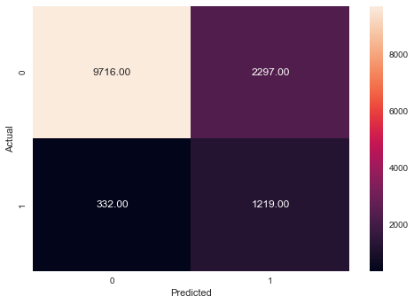

```
None
```

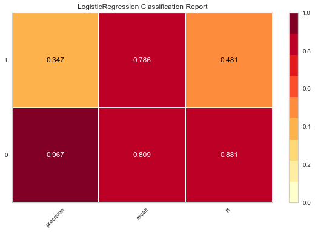

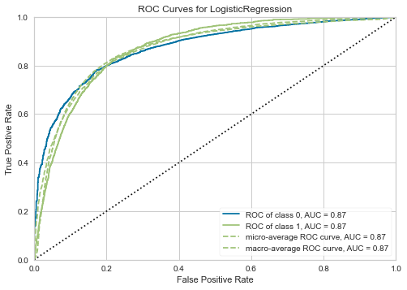

```python
algorithms(LogisticRegression(random_state=42,penalty='l1',C=0.5,solver='liblinear',class_weight='balanced'))
```

```python
MLA_columns = []
LR = pd.DataFrame(columns = MLA_columns)


row_index = 0
for algss in [model_s]:
    print(algss)

    MLA_name = algss.__class__.__name__
    LR.loc[row_index,'MLA Name'] = MLA_name
    LR.loc[row_index, 'Train Accuracy'] = round(algss.score(X_train, y_train), 4)
    LR.loc[row_index, 'Test Accuracy'] = round(algss.score(X_test, y_test), 4)
    LR.loc[row_index, 'Accuracy Score'] = round(accuracy_score(y_test, y_predict), 4)
    LR.loc[row_index, 'MAE'] = round(mean_absolute_error(y_test, y_predict), 4)
    LR.loc[row_index, 'Recall'] = round(recall_score(y_test, y_predict), 4)
    LR.loc[row_index, 'F1 Score'] = round(f1_score(y_test, y_predict), 4)
    LR.loc[row_index, 'ROC AUC Score'] = round(roc_auc_score(y_test, y_predict), 4)

    row_index+=1

LR
```

```
LogisticRegression(C=0.5, class_weight='balanced', dual=False,
          fit_intercept=True, intercept_scaling=1, max_iter=100,
          multi_class='warn', n_jobs=None, penalty='l1', random_state=42,
          solver='liblinear', tol=0.0001, verbose=0, warm_start=False)
```

|  | MLA Name | Train Accuracy | Test Accuracy | Accuracy Score | MAE | Recall | F1 Score | ROC AUC Score |
| --- | --- | --- | --- | --- | --- | --- | --- | --- |
| 0 | LogisticRegression | 0.8111 | 0.8062 | 0.8062 | 0.1938 | 0.7859 | 0.4812 | 0.7974 |

##### Observations

- To use Logistic Regression model to find out the level of metrics.

##### 2. using Decision Tree finding out the best fit to the dataset.

- Entropy
- Gini

##### Decision Tree - to tune the model and selected the best fit in Decision Tree.

- criterion='entropy',max_depth=4

```
model_selection: DecisionTreeClassifier(class_weight=None, criterion='entropy', max_depth=4,
            max_features=None, max_leaf_nodes=None,
            min_impurity_decrease=0.0, min_impurity_split=None,
            min_samples_leaf=1, min_samples_split=2,
            min_weight_fraction_leaf=0.0, presort=False, random_state=None,
            splitter='best')

----------------------------------------------------------------------------------------------------
Confusion Matrix:
```

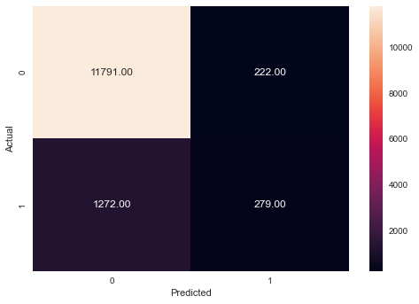

```
None
```

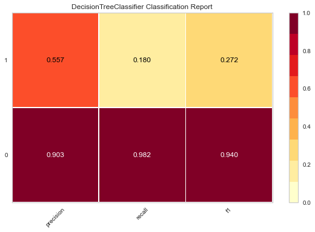

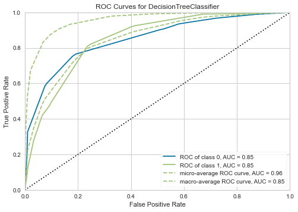

```python
from sklearn.tree import DecisionTreeClassifier

algorithms(DecisionTreeClassifier(criterion='entropy',max_depth=4))
```

```python
MLA_columns = []
DTE = pd.DataFrame(columns = MLA_columns)


row_index = 0
for algss in [model_s]:
    print(algss)

    MLA_name = 'DecisionTreeClassifier-entropy'
    DTE.loc[row_index,'MLA Name'] = MLA_name
    DTE.loc[row_index, 'Train Accuracy'] = round(algss.score(X_train, y_train), 4)
    DTE.loc[row_index, 'Test Accuracy'] = round(algss.score(X_test, y_test), 4)
    DTE.loc[row_index, 'Accuracy Score'] = round(accuracy_score(y_test, y_predict), 4)
    DTE.loc[row_index, 'MAE'] = round(mean_absolute_error(y_test, y_predict), 4)
    DTE.loc[row_index, 'Recall'] = round(recall_score(y_test, y_predict), 4)
    DTE.loc[row_index, 'F1 Score'] = round(f1_score(y_test, y_predict), 4)
    DTE.loc[row_index, 'ROC AUC Score'] = round(roc_auc_score(y_test, y_predict), 4)

    row_index+=1

DTE
```

```
DecisionTreeClassifier(class_weight=None, criterion='entropy', max_depth=4,
            max_features=None, max_leaf_nodes=None,
            min_impurity_decrease=0.0, min_impurity_split=None,
            min_samples_leaf=1, min_samples_split=2,
            min_weight_fraction_leaf=0.0, presort=False, random_state=None,
            splitter='best')
```

|  | MLA Name | Train Accuracy | Test Accuracy | Accuracy Score | MAE | Recall | F1 Score | ROC AUC Score |
| --- | --- | --- | --- | --- | --- | --- | --- | --- |
| 0 | DecisionTreeClassifier-entropy | 0.8892 | 0.8899 | 0.8899 | 0.1101 | 0.1799 | 0.2719 | 0.5807 |

###### Observations

- To use Decision Tree model and use the entropy, to find out the level of metrics.